# 6) EEG Data Reduction and Exploration

2026-06-30

```r
# Load in the package
library(tidyverse)
library(ggplot2)
library(kableExtra)
library(patchwork)
library(eegUtils) # electrode_locations(); # topoplot
```

### Problem with eegUtils- it messes with the filter() function

```r
library(conflicted)
conflicts_prefer(dplyr::filter)
```

We are quickly going to include **relative spectral density** or **proportional power spectra**.

This follows the formula:

Power that corresponds to a frequency divided by the power summed across all frequencies - which is calculated within **persons** and within **channels**!

```r
comb_FFT <- comb_FFT %>%
  group_by(ID, channel) %>%
  mutate(rel_power = power / sum(power, na.rm = TRUE)) %>%
  ungroup()
```

We can also transform these values into **log** and **logit** scale, where the former is done to the power spectra while the latter is done to the relative power spectra.

```r
# Introducing log power and logit relative power
comb_FFT <- comb_FFT %>%
  mutate(
    log_power = log(power),
    logit_rel_power = log(rel_power/(1 - rel_power))
  )
```

First 10 rows of the Behavioral and EEG Data

| ID | Sex | Age | Age_group | Spell_group | Condition | channel | frequency | power | rel_power | log_power | logit_rel_power |
| --- | --- | --- | --- | --- | --- | --- | --- | --- | --- | --- | --- |
| 10053 | F | 19 | 18-20 | high | Closed | AF3 | 0.50 | 0.3869194 | 0.0626456 | -0.949539 | -2.705568 |
| 10053 | F | 19 | 18-20 | high | Closed | AF3 | 0.75 | 0.2244688 | 0.0363435 | -1.494019 | -3.277721 |
| 10053 | F | 19 | 18-20 | high | Closed | AF3 | 1.00 | 0.1985951 | 0.0321543 | -1.616487 | -3.404527 |
| 10053 | F | 19 | 18-20 | high | Closed | AF3 | 1.25 | 0.1208590 | 0.0195681 | -2.113131 | -3.914091 |
| 10053 | F | 19 | 18-20 | high | Closed | AF3 | 1.50 | 0.1171857 | 0.0189734 | -2.143995 | -3.945562 |
| 10053 | F | 19 | 18-20 | high | Closed | AF3 | 1.75 | 0.1057793 | 0.0171266 | -2.246401 | -4.049849 |
| 10053 | F | 19 | 18-20 | high | Closed | AF3 | 2.00 | 0.0638917 | 0.0103446 | -2.750565 | -4.560889 |
| 10053 | F | 19 | 18-20 | high | Closed | AF3 | 2.25 | 0.0590657 | 0.0095633 | -2.829105 | -4.640218 |
| 10053 | F | 19 | 18-20 | high | Closed | AF3 | 2.50 | 0.0585812 | 0.0094848 | -2.837342 | -4.648535 |
| 10053 | F | 19 | 18-20 | high | Closed | AF3 | 2.75 | 0.0361087 | 0.0058463 | -3.321222 | -5.136081 |

### Visualizing the Power Spectra (Eyes Closed rsEEG) With the Regular Scale

#### General

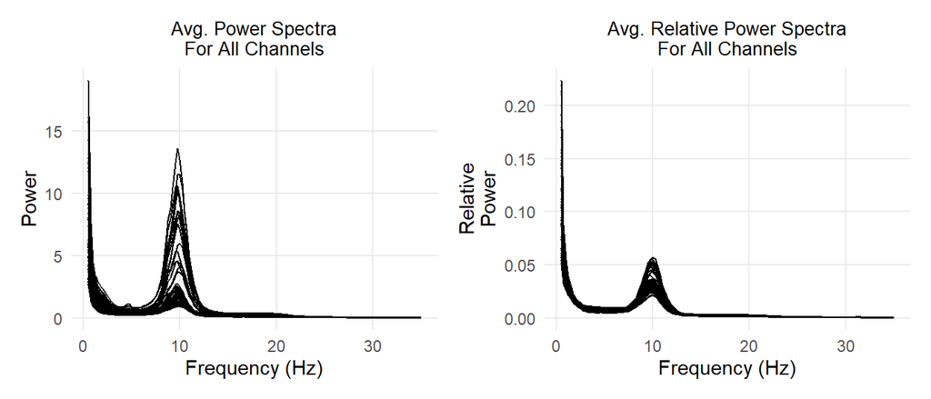

#### By Age Groups

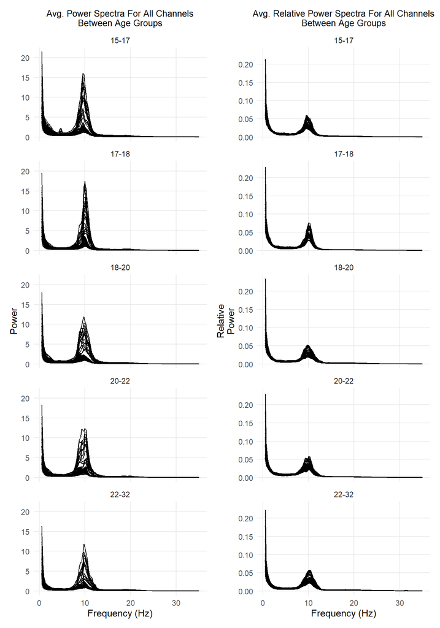

#### By Spelling Groups

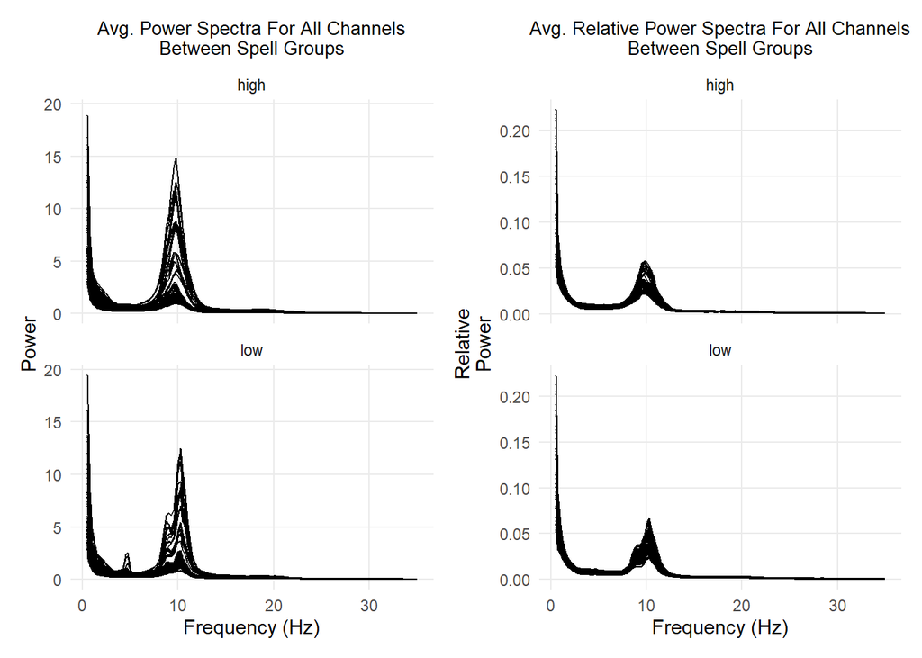

### Visualizing the Power Spectra (Eyes Closed rsEEG) With the Log and Logit Scale

#### General

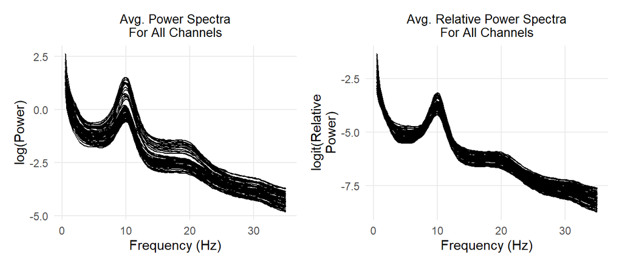

#### By Age Groups

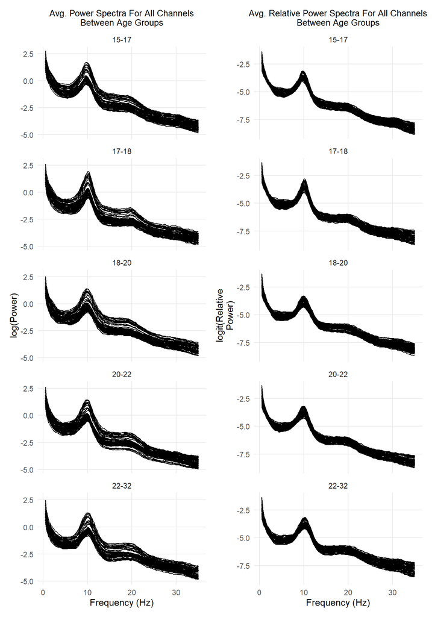

#### By Spelling Groups

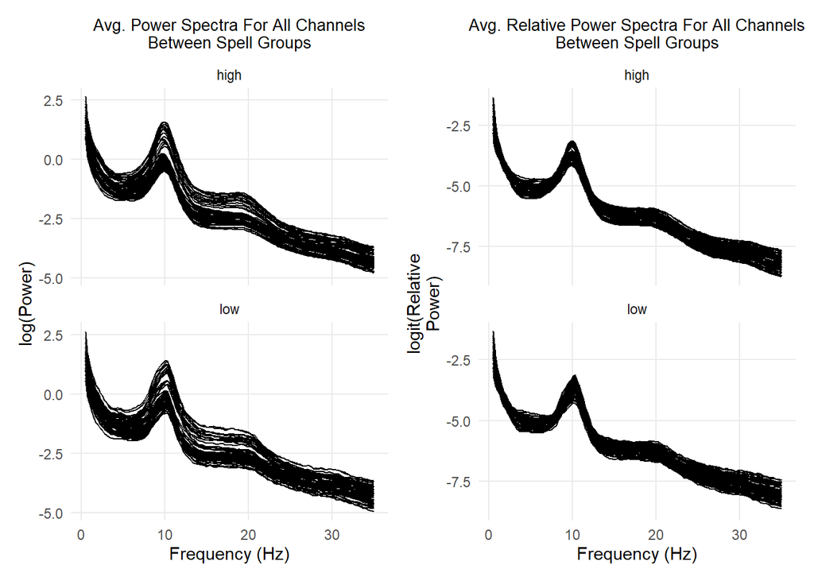

# Examining Alpha Rhythm Peak (Absolute Power Raw Scale)

Since we have eyes-closed rsEEG, it would be interesting to investigate the alpha rhythm peak across subjects from an aggregate of the posterior electrodes. This will be done for the raw scale.

This is typically between 8-12 Hz. To be more conservative, we will pick between 7-13 Hz.

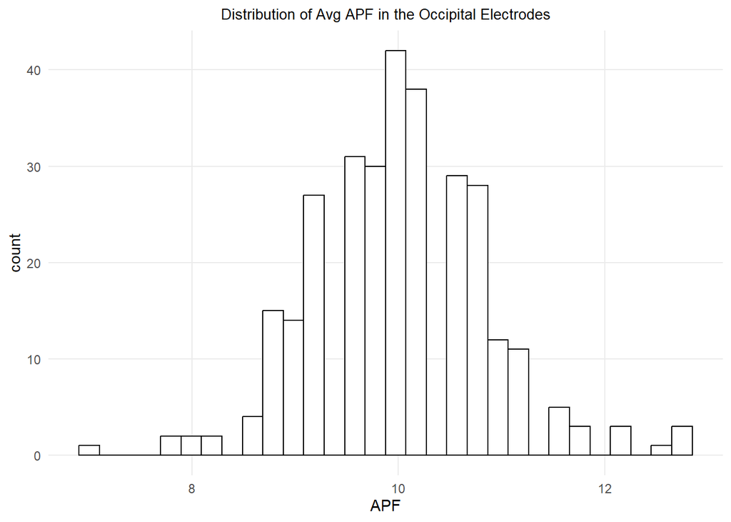

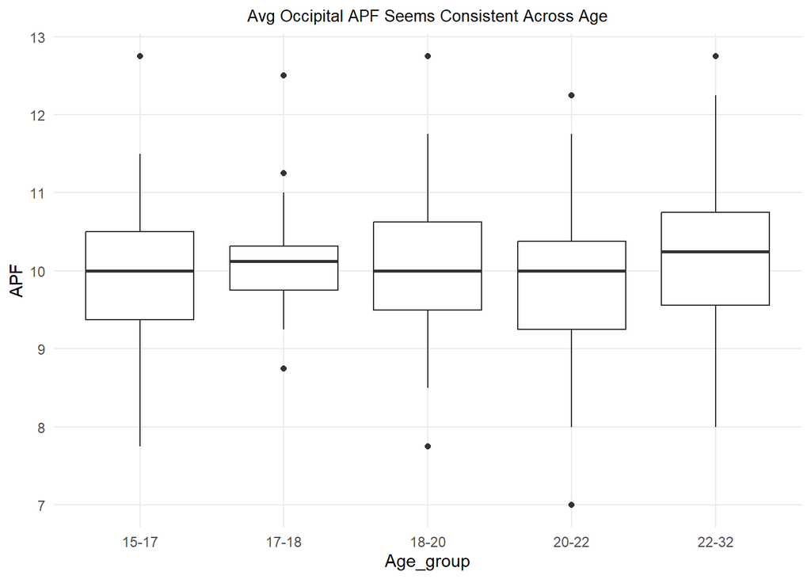

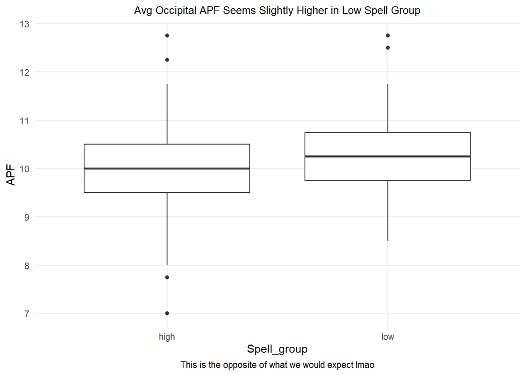

# Introducing region and Frequency Band Variables (No Averaging)

Here we will introduce **frequency band** (FB), **region**, **hemisphere**, and **region_hemisphere** as factors. These factors are designed to simplify our data, since right now each recording has power values across a broad range of frequencies for each of the 62 electrodes. Eventually we will use these factors to reduce the dimensions of the data, but for now we used the `summary()` function in combination with the `group_by()` function to keep the same dimension. This is so that in subsequent sections we can plot the power spectra without issues.

Also, all recordings below are **eyes closed** only!

The frequency bands chosen were based on an extensive review of frequency bands looked at across several papers (check the rsEEG power changes with development excel sheet).

Why use these different frequency bands? What do they represent in terms of informing us about the brain?

Delta:

Delta is the clearest developmental marker in your table. Neurophysiologically, high delta power reflects large-amplitude, highly synchronous slow activity across neuronal populations. In development, elevated delta is interpreted as a marker of neural immaturity, greater synaptic density, and less refined cortical organization. Whitford et al. specifically frame slow-wave power as arising from spatially coherent synaptic activity, especially local synchrony among pyramidal neurons; as synaptic pruning reduces redundant dendrites, spines, and axon terminals, scalp EEG amplitude decreases. This makes delta especially sensitive to adolescent cortical maturation. See rows 8 and 9, and also rows 3, 4, and 6. Expected change: delta absolute power should decrease from adolescence into adulthood, with the largest and most robust declines compared with faster bands. This decrease should be nonlinear/decelerating, with stronger change during adolescence and a plateau/asymptote by the mid-20s. This is especially supported by rows 8 and 9. Topographically, the developmental decrease is often widespread, but several rows suggest posterior regions mature earlier and frontal/association cortices show later maturation. See rows 2, 3, 4, 8, and 9.

Theta:

Theta also reflects slow-wave developmental immaturity, but it is often discussed as slightly more cognitively/network-related than delta. In your rows, theta is tied to maturation of thalamo-cortical and cortico-cortical systems, reduction of slow-wave dominance, and the shift toward faster dominant frequencies. Cragg et al. describe delta/theta decreases as part of standard adolescent maturation and connect them to synaptic pruning and white matter development. See rows 4, 6, 8, and 9. Expected change: theta absolute power should decrease from adolescence into adulthood, often strongly and sometimes even more steeply than delta depending on the study. Gasser et al. note that theta showed one of the strongest developmental decreases and that theta is gradually superseded by alpha activity during development. See row 2. Cragg et al. also report that delta and theta show the largest developmental decreases, with reductions across the scalp. See row 4.

Alpha 1 (Slow):

Alpha1 is lower alpha, and developmentally it often behaves more like the slow bands than like mature adult alpha. In your table, alpha1 is described as decreasing with age or being reduced as the brain shifts from slower alpha toward faster alpha. Gasser et al. describe alpha1 as part of a maturational sequence where alpha1 supersedes theta, and alpha2 later supersedes alpha1. See row 2. Cragg et al. report that alpha1 absolute power decreases over time. See row 4. Lüchinger et al. also report adolescent-adult differences below 10 Hz, which maps well onto alpha1. See row 8. Expected change: alpha1 should generally decrease from adolescence into adulthood, especially if measured as absolute power. Conceptually, this reflects movement away from slower, less mature dominant rhythms and toward faster alpha organization. It is also part of the broader developmental “frequency shift” from slower to faster rhythms. See rows 2, 4, 6, and 8.

Alpha2 (Fast):

Alpha2 is the more mature upper-alpha range. It is closely connected to the adult posterior alpha rhythm and peak alpha frequency. Neurophysiologically, alpha is often linked to thalamo-cortical information exchange, cortical idling/inhibition, and coordinated rhythmic activity in posterior networks. In your sheet, alpha2 is also tied to white matter maturation and increased conduction velocity, because faster neural communication supports faster rhythmic oscillations. See rows 4 and 6. Expected change: alpha2 is not expected to simply decrease like delta/theta. It may increase in relative power during development, especially posteriorly, even when absolute power is stable or eventually decreases. Gasser et al. describe alpha2 as increasing until around age 13 and then decreasing, producing an inverted-U pattern. See row 2. Cragg et al. report that alpha2 was the only range that did not show an age-related absolute power decrease, while relative alpha2 increased posteriorly. See row 4. For adolescents into adulthood, I would expect alpha2 to be relatively stable or show weaker decreases than slow bands, while peak alpha frequency shifts upward and posterior alpha organization becomes more adult-like. See rows 4, 6, and 8.

Beta1 (WONT USE):

Beta1 reflects faster, lower-amplitude cortical activity and more mature cortical network dynamics. Compared with delta/theta, its developmental interpretation is less straightforward. Some rows describe beta as part of the broader shift toward faster rhythms with maturation, especially in relative power, while absolute beta may decrease slowly or show weaker age effects. See rows 2, 4, 6, and 8. Expected change: beta1 absolute power may decrease slightly with age, but the effect is usually weaker and less robust than delta/theta. In relative terms, beta may increase because slow-wave power decreases more strongly. Gasser et al. found beta1/beta2 absolute power slowly declined, while fast bands increased in relative magnitude. See row 2. Cragg et al. found beta absolute power decreased with age, but relative beta increased. See row 4. Lüchinger et al. found higher beta frequencies did not clearly distinguish adolescents from adults. See row 8. So for your project, beta1 should be treated as a secondary/more exploratory maturational marker.